# Main figures for the analyses of results

MGH

2026-07-21

This file contains code to generate the main figures from the paper: “Mapping effective population size across a three-dimensional life-history framework of species and populations to support broad-scale Ne500 indicator implementation” by Harribey et al. 202X

To rerun this code, you will need the two files available in the folder /scripts/Figures_analyses_of_results:  
- “summary_by_pop_tableS7.csv” This file corresponds to the Supplementary table S7 with modified column names, readable in R.  
- “complementary_info_on_legacy_species.csv”

# 1 Set-up

Package loading

```r
library(dplyr)
library(tidyverse)
library(purrr)

#for graphical purpose
library(ggplot2)
library(ggh4x)
library(ggsignif)
library(ggrepel)
library(vioplot)
library(patchwork)
library(cowplot)
library(plotly)
```

Get the dataset in your R space

```r
#you might need to run: setwd("your_own_folders_path")
#Load the files in your R space
results_by_pop <- read.csv("summary_by_pop_tableS7.csv", sep=";")

#add a column that will be needed for the analyses
results_by_pop <- results_by_pop %>% mutate(Dataset_Markertype=paste0(Dataset,"_",Marker_type))

complementary_info_species <- read.csv("complementary_info_on_legacy_species.csv", sep=";")

#combine them into one single table
FULL_TAB <- results_by_pop %>% left_join(complementary_info_species, by="Dataset_Markertype")
```

Manual color/shape scales:

```r
#For each dataset
colors_DatasetMarker <- c(
  #HighRS from slow to fast
  "Symphonia_globulifera_Schmitt2021_Gargiulo2024_SNP"="orangered",
  "Cypripedium_calceolus_Gargiulo_2023_SSR"="indianred",
  "Cypripedium_calceolus_Gargiulo_2023_SNP"="brown",
  "Mya_arenaria_DeNoia_2020_SSR"="darkorange",

  #IntermRS from slow to fast
  "Sardina_pilchardus_Antoniou_2023_SNP"="royalblue",
  "Pinus_pinaster_Milesi_2024_SNP"="cyan2", #"darkturquoise"
  "Fagus_sylvatica_Milesi_2024_SNP"="steelblue1",
   "Canis_lupus_Silva_2018_K11_SSR"="darkblue", #"navyblue",
  "Canis_lupus_Szewczyk_2019_SSR" ="mediumblue", #"darkslateblue","darkblue"

  "Rana_arvalis_Cox_2024_SSR"="darkolivegreen2",
  "Coenagrion_mercuriale_Leveque_2024_pop_2021_SSR"="limegreen",
  "Coenagrion_mercuriale_Leveque_2024_pop_2022_SSR"="limegreen",
   "Coenagrion_mercuriale_Leveque_2024_pop_2021_SNP"="chartreuse",
 "Coenagrion_mercuriale_Leveque_2024_pop_2022_SNP"="chartreuse",
  "Alytes_obstetricans_Barratt_2024_SSR"="darkolivegreen4",
  "Alytes_obstetricans_Barratt_2024_SNP"="darkolivegreen3",
 "Gasterosteus_aculeatus_Raeymaekers_2008_SSR"="springgreen4",

  #LowRS from slow to fast
  "Ursus_arctos_Kopatz_2024_SNP"="magenta4",
  "Ursus_arctos_Kopatz_2021_SSR"="purple2",
 "Raja_clavata_Marandel_2020_SNP"="purple4",
 "Pinus_sylvestris_Milesi_2024_SNP"="darkorchid3",
  "Antirrhinum_charidemi_HeuertzForrest_2024_SSR"="orchid",

  "Passer_domesticus_Hagen_2020_SNP"="violetred",
  "Passer_domesticus_Baalsrud_2013_pop_1994_SSR"="hotpink",
 "Passer_domesticus_Baalsrud_2013_pop_2000_SSR"="hotpink",
 "Passer_domesticus_Baalsrud_2013_pop_2006_SSR"="hotpink",
 "Graellsia_isabellae_GonzalesCastellano_2023_SSR"="magenta",
 "Barbastella_barbastellus_Razgour_2024_SNP"="salmon2"
)

# For species
colors_Species_as_other_Neresults <- c(
  "Passer domesticus"="hotpink",
  "Fagus sylvatica"="steelblue1",
  "Pinus pinaster"="cyan2",
  "Pinus sylvestris"="darkorchid3",
  "Cypripedium calceolus"="indianred",
 "Symphonia globulifera"="orangered",
 "Canis lupus"="darkblue",
 "Rana arvalis"="darkolivegreen3",
 "Ursus arctos"="purple2",
 "Barbastella barbastellus"="salmon2",
 "Sardina pilchardus"="royalblue",
 "Antirrhinum charidemi"="orchid",
 "Raja clavata"="purple4",
 "Alytes obstetricans"="darkolivegreen4",
 "Coenagrion mercuriale"="limegreen",
 "Graellsia isabellae"="magenta",
 "Mya arenaria"="darkorange",
 "Gasterosteus aculeatus"="springgreen4"
)

# For biogeographic categories
color_biogeo_pos <- c("core"="#865640FF",
                              "subedge"="#BD582CFF",
                              "edge"="#E48312FF",
                              "island"="#9B8357FF",
                              "isle"="#C2BC80FF",
                              "endemic"="#94A088FF")

#Points shape
#Type of marker
shape_Markertype <- c("SSR"=17, "SNP"=15)

#Organism type
shape_OrgType <- c(
  #for points shape according organism type
  "Aves" = 18,
  "Herbaceous perennial" = 16,
  "Tree" = 17,
  "Actinopterygii" = 23,
  "Elasmobranchii" = 12,
  "Amphibia" = 8,
  "Bivalvia" = 21,
  "Insecta" = 25,
  "Mammalia" = 13)
```

# 2 Main figures

## 2.1 Figure 2 - Assignment of legacy species to the LHT variation plane categories

In the case we didn’t find a related species for our legacy species in Capdevila PCA, we add the coordinate by hand, as an educated guess, in the center of a given square. To make them easier to read, we have slightly spaced out these points.

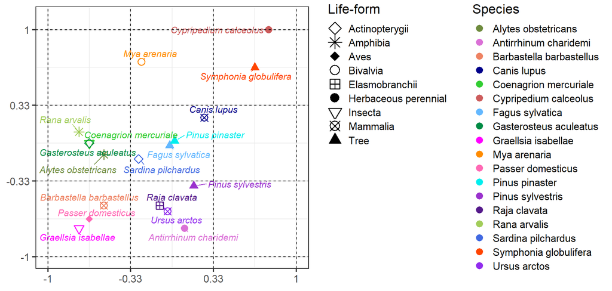

```r
#some set-up for the graphics
breaks <- seq(-1, 1, length.out = 4) #to split our plan in 9 subsquares

FULL_TAB %>% distinct(Species, .keep_all = TRUE) %>%
  ggplot(aes(x=PC1_educ_guess_spread, y=PC2_educ_guess_spread, label=Species, color=Species, shape=OrganismType))+
  geom_point(size=3.5, stroke=1) +
  geom_text_repel(aes(label = Species), show.legend = FALSE, size = 4,
          max.overlaps = 20,force = 2,box.padding = 0.35,point.padding = 0.45,#point.padding = unit(10, "mm"),
          min.segment.length = 0.1,
          fontface = "italic")+
    theme_bw(base_size = 16)+
  scale_shape_manual(values=shape_OrgType, na.value = 18)+
  scale_color_manual(values=colors_Species_as_other_Neresults, na.value = "grey")+
  scale_x_continuous(limits = c(-1, 1), breaks = breaks, labels=round(breaks, 2)) +
  scale_y_continuous(limits = c(-1, 1.1), breaks = breaks, labels=round(breaks, 2)) +
  geom_vline(xintercept = breaks, color = "black", linetype = "dashed") +
  geom_hline(yintercept = breaks, color = "black", linetype = "dashed")+
  labs(x = NULL, y = NULL)+
  guides(color = guide_legend(order = 2, title = "Species",
                         override.aes = list(size = 3),
                          ncol = 1,
                          byrow = TRUE),
        shape = guide_legend(order = 1, title = "Life-form",
                         override.aes = list(size = 5),
                      ncol = 1))+
  theme(legend.box = "horizontal")
```

## 2.2 Figure 3 - NeLD estimates of populations with their CI

(CI: Confidence Interval)

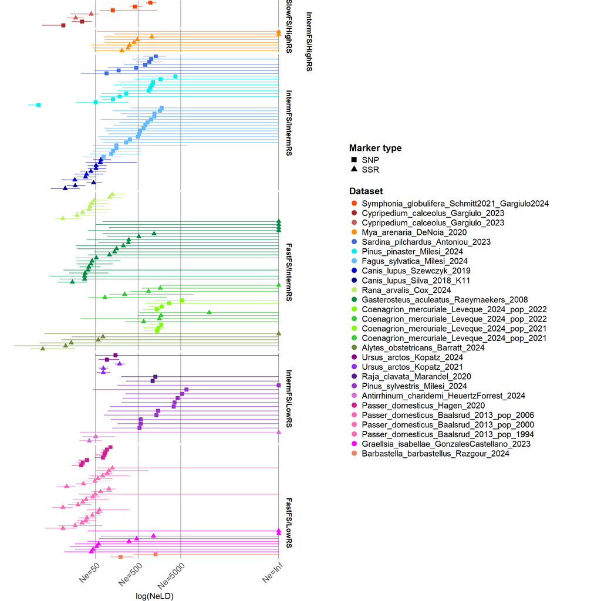

```r
# Categories of the LHT var plan to include in the graph (here the one with species)
deg_levels <- c("SlowFS/HighRS",#"SlowFS/IntermRS",#"SlowFS/LowRS",
                "IntermFS/HighRS",#"FastFS/HighRS",
                "IntermFS/IntermRS","FastFS/IntermRS",
                "IntermFS/LowRS","FastFS/LowRS")

# 1. Create all the graphics of the subsquares without their legend
create_subplot <- function(deg_level) {

  data_subset <- FULL_TAB %>%
    filter(Catego_LHT_plan == deg_level) %>%
    arrange(Dataset, Marker_type, NeLD) %>%
    mutate(line_unique_id = paste0(Dataset,Marker_type,Population_name),
           line_unique_id = factor(line_unique_id, levels = unique(line_unique_id)))

  ggplot(data_subset, aes(x = log(NeLD), y = line_unique_id,
                         color = Dataset_Markertype, shape = Marker_type)) +
    geom_point(size = 3) +
    geom_errorbar(aes(xmin = log(JK_CI_down), xmax = log(JK_CI_up)),
                  width = 0.2, position = position_dodge(0.9)) +

    labs(x = ifelse(deg_level == last(deg_levels),
                   "log(NeLD)", ""),
         y = "", tag = deg_level) +

    scale_x_continuous(
        limits = c(0.2, 14),
        breaks = c(log(50), log(500), log(5000), log(999999)),
        labels = c("Ne=50", "Ne=500", "Ne=5000", "Ne=Inf"),
        minor_breaks = NULL) +

    scale_color_manual(values = colors_DatasetMarker) +
    scale_shape_manual(values = shape_Markertype) +

    theme_minimal() +
    theme(
      panel.grid.major = element_blank(), panel.grid.minor = element_blank(),
      axis.text.x = if (deg_level == last(deg_levels))
                      element_text(angle = 45, hjust = 1, size = 15)
                    else element_blank(),
      axis.title.x = if (deg_level == last(deg_levels))
                       element_text(size = 15)
                     else element_blank(),
      panel.grid.major.x = element_line(color = "grey50"),
      axis.text.y = element_blank(),
      legend.position = "none"  # NO LEGEND
    )+
    theme(plot.tag = element_text(size = 15, angle = 270, vjust = 1.5))
}

# 2. Create a graph that contains the whole legend
# (avoid problem while we are subsetting the dataset)
create_manual_legend <- function() {
  # Full table with all the data
  legend_data <- FULL_TAB %>%
    mutate(Catego_LHT_plan = factor(Catego_LHT_plan, levels = deg_levels)) %>%
    arrange(Catego_LHT_plan, desc(Dataset)) %>%
    select(Dataset_Markertype, Marker_type) %>%
    distinct() %>%
    mutate(
    Dataset_Markertype = factor(Dataset_Markertype, levels = unique(Dataset_Markertype)),
    Marker_type = factor(Marker_type, levels = unique(Marker_type))
  )

  legend_plot <- ggplot(legend_data, aes(color = Dataset_Markertype, shape = Marker_type)) +
    geom_point(aes(x = 1, y = 1), size = 4, alpha = 0) +  # No points

    #Shape the legend beautifully by hand
    scale_color_manual(
      values = colors_DatasetMarker,
      labels = ~gsub("_SSR|_SNP", "", .x),
      name = "Dataset"
    ) +
    scale_shape_manual(
      values = shape_Markertype,
      name = "Marker type"
    ) +

    guides(
      color = guide_legend(
        order = 2,
        title = "Dataset",
        override.aes = list(size = 4, alpha = 1),
        ncol = 1
      ),
      shape = guide_legend(
        order = 1,
        title = "Marker type",
        override.aes = list(size = 4, alpha = 1),
        ncol = 1
      )
    ) +

    theme_void() +
    theme_minimal()+
    theme(
      legend.position = "right",
      legend.box = "vertical",
      legend.title = element_text(size = 17, face = "bold"),
      legend.text = element_text(size = 15)
    )

  return(legend_plot)
}

# 3. Create the graphics for each category and the unique legend
plots2 <- map(deg_levels, create_subplot)

## legend
legend_plot <- create_manual_legend()
legend_only <- get_legend(legend_plot)
# 4. Combine the graphics according the LHTs plan
# heights calculation
# heights <- FULL_TAB %>%
#   group_by(Catego_LHT_plan) %>%
#   summarise(n = n_distinct(Dataset_Markertype), .groups = 'drop') %>%
#   arrange(match(Catego_LHT_plan, deg_levels)) %>%
#   pull(n)
heights <- c(1.2,1,6,7,4,5) #readapted based on results obtained just above

plots_combined <- wrap_plots(plots2, ncol = 1, heights = heights) &
  theme(
    plot.margin = margin(t = 0.5, r = 5, b = 0.5, l = 5, unit = "pt"),
    plot.tag.position = c(1, 0.5),
    plot.tag = element_text(size = 13, angle = 270, color = "black", face = "bold")
  )
## specific features
plots_combined[[1]] <- plots_combined[[1]] +
  theme(plot.tag.position = c(1, 0.1))
plots_combined[[2]] <- plots_combined[[2]] +
  theme(plot.tag.position = c(1.07, 0.5))

# 5. FINAL PLOT: Graphics + legend
final_plot <- plot_grid(plots_combined, legend_only,
                       ncol = 2, rel_widths = c(2, 2))

final_plot
```

## 2.3 Figure 4

### 2.3.1 A) Biogeographic position

The only endemic population are the 3 populations from Antirrhinum charidemi, so we grouped them with the isle position.

```r
# gather endemic population into the "isle" category
FULL_TAB <- FULL_TAB %>% mutate(Biogeographic_pos_pop=case_when(
                                Biogeographic_pos_pop == "endemic" ~ "isle",
                                TRUE ~ Biogeographic_pos_pop))

#levels
FULL_TAB$Biogeographic_pos_pop <- factor(FULL_TAB$Biogeographic_pos_pop,
                                            levels=c("core","subedge","edge",
                                                     "island","isle"))
```

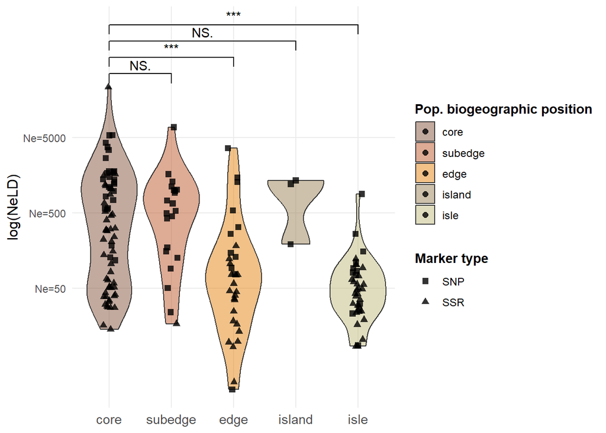

```r
FULL_TAB %>% filter(NeLD != 999999) %>%
ggplot(aes(x = Biogeographic_pos_pop, y = log(NeLD),
                        fill = Biogeographic_pos_pop)) +
  geom_violin(adjust = 1, alpha = 0.5, scale = "width") +
  geom_jitter(aes(shape = Marker_type), size = 2, alpha = 0.8,
              position = position_jitter(width = 0.1)) +
  labs(y = "log(NeLD)") +
  scale_shape_manual(values = shape_Markertype,
                     name = "Marker type") +
  scale_fill_manual(values = color_biogeo_pos,
                    name="Pop. biogeographic position") +
  scale_y_continuous(
        #limits = c(0.8, 10.2),
        breaks = c(log(50), log(500), log(5000)), #, log(999999)
        labels = c("Ne=50", "Ne=500", "Ne=5000"), #, "Ne=Inf"
        minor_breaks = NULL)+
  theme_minimal() +
  theme(axis.text.x = element_text(size=11),
        axis.title.x = element_blank(),
        axis.title.y = element_text(size=12),
        legend.title = element_text(size = 11, face = "bold"),
      legend.text = element_text(size = 9))+

  # add significant differences between mean
  geom_signif(comparisons=list(c("core","subedge"),
                               c("core","edge"),
                               c("core","island"),
                               c("core","isle")),
              #test = "t.test",
              test = "wilcox.test", #non-parametric test, by default
              map_signif_level = TRUE,
              #y_position = c(10,11,12,13))
              y_position = c(10,10.5,11,11.5))
```

### 2.3.2 B) Regressions of NeLD estimates according to population differentiation statistics across categories

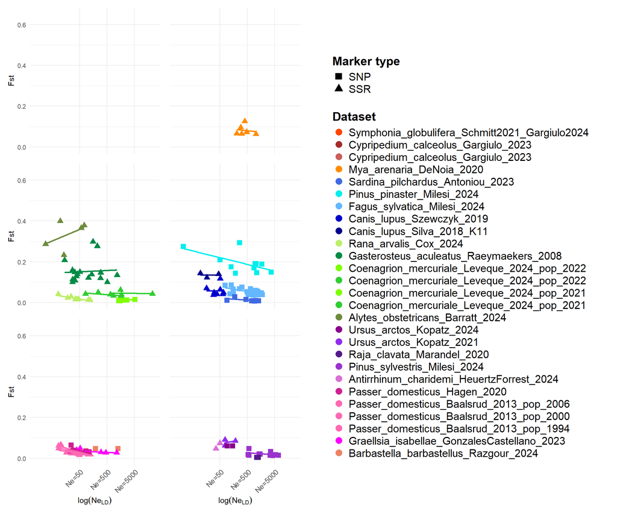

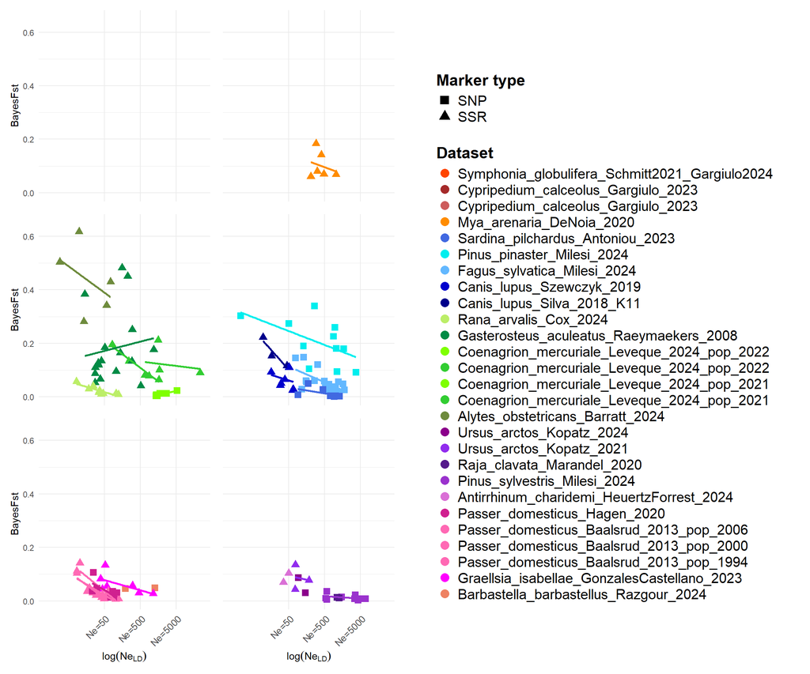

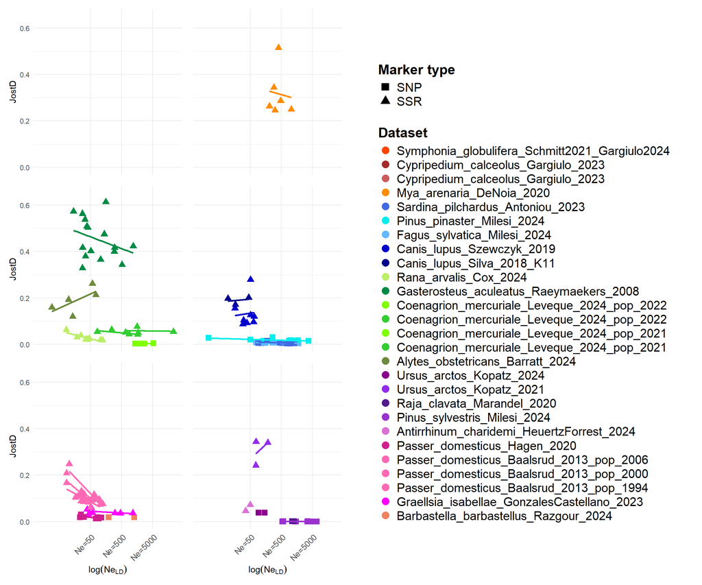

```r
#only keep variable that are not too correlated to another one
var_to_plot4 <- c("Fst","BayesFst","JostD")
levels_to_plot <- c("FastFS/HighRS", "IntermFS/HighRS", "FastFS/IntermRS", "IntermFS/IntermRS", "FastFS/LowRS", "IntermFS/LowRS")

for(i in 1:length(var_to_plot4)) {

      var_y <- var_to_plot4[i]


# Create plots
plots <- lapply(levels_to_plot, function(level_name) {
  data_subset <- FULL_TAB %>% filter(Catego_LHT_plan == level_name,
                                     !is.na(NeLD),
                                     NeLD < 999999)

  #data_subset$Dataset_Markertype <- factor(data_subset$Dataset_Markertype, levels = levels(FULL_TAB$Dataset_Markertype))

  # Index du plot (pour détecter la colonne dans la grille)
  idx <- which(levels_to_plot == level_name)

  # Si dans la 1ère colonne (idx %% 3 == 1), on garde l’axe y visible
  show_y <- (idx %% 2 == 1)
  show_x <- (idx >= 5)

  ggplot(data_subset, aes(x=log(NeLD),y=!!sym(var_y),
                          color=Dataset_Markertype, shape=Marker_type))+
  geom_point(size=3)+
  geom_smooth(data = . %>% filter(NeLD < 999999) %>%
                group_by(Dataset_Markertype) %>%
                filter(n() > 2) %>%
                ungroup(),
            method="lm", se=FALSE)+
  scale_color_manual(values=colors_DatasetMarker) +
  scale_shape_manual(values=shape_Markertype)+

    scale_x_continuous(
        limits = c(0.2, 10.2),
        breaks = c(log(50), log(500), log(5000)), #, log(999999)
        labels = c("Ne=50", "Ne=500", "Ne=5000"), #, "Ne=Inf"
        minor_breaks = NULL) +

    scale_y_continuous(limits = c(0, 0.65))+

    labs(#title = level_name,
      y = var_y,
        x = expression(log(Ne[LD]))) +
    theme_minimal() +

    theme(
      axis.title.x=if (show_x) element_text() else element_blank(),
      axis.text.x = if (show_x) element_text(angle = 45, hjust = 1, size = 10) else element_blank(),
      axis.title.y = if (show_y) element_text() else element_blank(),
      axis.text.y = if (show_y) element_text() else element_blank(),
      axis.ticks.y = element_blank(),
      legend.position="none",
      plot.title = element_text(size = 10, face = "bold")
    )

  })

  # Combine graphics and add the legend
  plots_combined <- wrap_plots(plots, nrow = 3, ncol = 2)


  final_plot <- plot_grid(plots_combined, legend_only,
                       ncol = 2, rel_widths = 1.5)
  print(final_plot)
}
```

## 2.4 Figure 5 - 3D representation

We are representing NeLD estimates according to the position of species in our categorization framework that includes the categorization of species within the LHT variation plane and a 3rd axis using *BayesFst* values for each population.

```r
#1.create a sub dataset with the columns that we are interested in for this figure
for_the_cube <- FULL_TAB %>% select(Species, Dataset_Markertype,
                                    BayesFst, NeLD,
                                    PC1_educ_guess_spread,PC2_educ_guess_spread)
levels_variable_numeric <- levels(as.factor(for_the_cube$Dataset_Markertype))
manual_color_scale <- colors_DatasetMarker[levels_variable_numeric]

#2.Main graphic --> the "cube"
p1 <- for_the_cube %>% filter(NeLD < 8000) %>%
      plot_ly(x = ~PC1_educ_guess_spread,
              y = ~PC2_educ_guess_spread,
              z = ~BayesFst,
              color = ~Dataset_Markertype,
              colors = manual_color_scale,
              size = ~NeLD,
              type = "scatter3d",
              mode = "markers",
              marker = list(sizemin = 10,
                            sizeref = 2,
                            sizemode = "diameter",
                            opacity = 0.6),
              showlegend=FALSE) %>%
    plotly::layout(scene = list(
      xaxis = list(
        title = "FS continuum",
        range = c(-1, 1),
        tickvals = round(seq(-1, 1, length.out = 4),2),
        zeroline = FALSE,
        titlefont = list(size = 12),
       tickfont = list(size = 10)),
      yaxis = list(
        title = "RS continuum",
        range = c(-1, 1),
        tickvals = round(seq(-1, 1, length.out = 4),2),
      zeroline = FALSE,
      titlefont = list(size = 12),
       tickfont = list(size = 10)),
      zaxis = list(
        title = "BayesFst",
        range = c(0, 0.7),
        tickvals = round(seq(0, 0.7, length.out = 4),2),
      zeroline = FALSE,
      titlefont = list(size = 12),
       tickfont = list(size = 10)),
      # Angle of view
      camera = list(eye = list(x = 2, y = -2, z = 0.6)),
      aspectmode = "cube"))

#3.A second graphic with the legend only
# Values for the scale
ne_values <- c(100, 500, 1000, 5000)

# To simplify we use a 2D graphic here
scale_plot <- plot_ly() %>%
  add_markers(
    x = rep(1, length(ne_values)),
    y = ne_values, #y_positions,
    size = ne_values,
    marker = list(
      sizemin = 2,
      sizeref = 2,   # Same value as principal graphic
      sizemode = "diameter",
      opacity = 0.5,
      color = 'gray'
    ),
    text = ~paste("NeLD =", ne_values),
    hoverinfo = "text",
    showlegend = FALSE
  ) %>%
  layout(
    title = "",
    xaxis = list(showticklabels = FALSE, showgrid = FALSE, zeroline = FALSE, title = ""),
    yaxis = list(showticklabels = FALSE, showgrid = FALSE, zeroline = FALSE, title = ""),
    margin = list(l = 100, r = 100, t = 50, b = 50)
  ) %>%
  add_annotations(
   x = rep(1, length(ne_values)),
    y =ne_values, #y_positions,
    text = paste("NeLD =", ne_values),
    xanchor = "left",
    xshift = 30,
    showarrow = FALSE
  )


# 4.Combine the 2 subplots
combined3D_FstBay_leg <- subplot(p1, scale_plot, nrows = 1, widths = c(0.8, 0.2),
        which_layout = 1) %>%
  layout(showlegend = TRUE,
         xaxis2 = list(domain = c(0.7, 0.9)),
         yaxis2 = list(domain = c(0.3, 0.7)))
combined3D_FstBay_leg
```

[interactive chart not shown]

```r
#save the plot
#htmlwidgets::saveWidget(combined3D_FstBay_leg, "cube_3D_fstBay.html")
```

NB: I removed the Infinite estimates for visual purposes.

You also can choose the angle you’re the most interested in as well as zoom in and out.